# Numerical Exploration of Limits Through Sequences

In this activity, we will explore what it means for a sequence to **converge**, to **diverge to infinity**, or to **fail to converge**.

The main idea is:

> We do not only care about the first few terms of a sequence.  
> We care about what happens in the **tail** of the sequence.

The **tail** of a sequence means the terms far out in the sequence, after many terms have already passed.

## Part 1: A Sequence That Converges

Consider the sequence

$$ a_n = 1 + \frac{1}{n}. $$

Let's look at the first 10 terms.

```python
for n in range(1, 11):
    a = 1 + 1/n
    print("a_" + str(n) + " =", a)
```

```
a_1 = 2.0
a_2 = 1.5
a_3 = 1.3333333333333333
a_4 = 1.25
a_5 = 1.2
a_6 = 1.1666666666666667
a_7 = 1.1428571428571428
a_8 = 1.125
a_9 = 1.1111111111111112
a_10 = 1.1
```

### Question 1

What value do the terms seem to be getting close to?

Write your answer in words:

> The sequence seems to be getting close to ...

Now let's look farther out in the sequence. These are terms from the **tail** of the sequence.

```python
for n in range(50, 61):
    a = 1 + 1/n
    print("a_" + str(n) + " =", a)
```

```
a_50 = 1.02
a_51 = 1.0196078431372548
a_52 = 1.0192307692307692
a_53 = 1.0188679245283019
a_54 = 1.0185185185185186
a_55 = 1.018181818181818
a_56 = 1.0178571428571428
a_57 = 1.0175438596491229
a_58 = 1.0172413793103448
a_59 = 1.0169491525423728
a_60 = 1.0166666666666666
```

### Question 2

Do the tail terms support your guess from Question 1?

Explain briefly.

Let's plot the first 100 terms.

[output not shown]

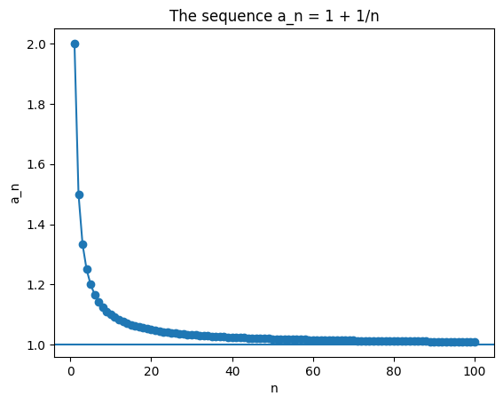

```python
import matplotlib.pyplot as plt

n_values = []
a_values = []

for n in range(1, 101):
    a = 1 + 1/n
    n_values.append(n)
    a_values.append(a)

plt.plot(n_values, a_values, marker='o')
plt.axhline(1)
plt.xlabel("n")
plt.ylabel("a_n")
plt.title("The sequence a_n = 1 + 1/n")
plt.show()
```

The horizontal line in the graph is at $y=1$.

The terms get closer and closer to this line. We say

$$ \lim_{n\to\infty} \left(1+\frac{1}{n}\right)=1. $$

## Your Turn 1

Consider the sequence

$$ b_n = 2 + \frac{3}{n}. $$

Edit the code below to print the terms from $b_{50}$ to $b_{60}$.

What value does this sequence seem to approach?

```python
# Your code here
```

## Part 2: A Sequence Can Converge Even If It Oscillates

Now consider

$$ a_n = \frac{(-1)^n}{n}. $$

```python
for n in range(1, 11):
    a = ((-1)**n)/n
    print("a_" + str(n) + " =", a)
```

```
a_1 = -1.0
a_2 = 0.5
a_3 = -0.3333333333333333
a_4 = 0.25
a_5 = -0.2
a_6 = 0.16666666666666666
a_7 = -0.14285714285714285
a_8 = 0.125
a_9 = -0.1111111111111111
a_10 = 0.1
```

The sequence oscillates, but the terms are getting closer to 0.

Let's look at the tail.

```python
for n in range(50, 61):
    a = ((-1)**n)/n
    print("a_" + str(n) + " =", a)
```

```
a_50 = 0.02
a_51 = -0.0196078431372549
a_52 = 0.019230769230769232
a_53 = -0.018867924528301886
a_54 = 0.018518518518518517
a_55 = -0.01818181818181818
a_56 = 0.017857142857142856
a_57 = -0.017543859649122806
a_58 = 0.017241379310344827
a_59 = -0.01694915254237288
a_60 = 0.016666666666666666
```

### Question 3

Even though the signs alternate, what value do the terms seem to approach?

Explain briefly.

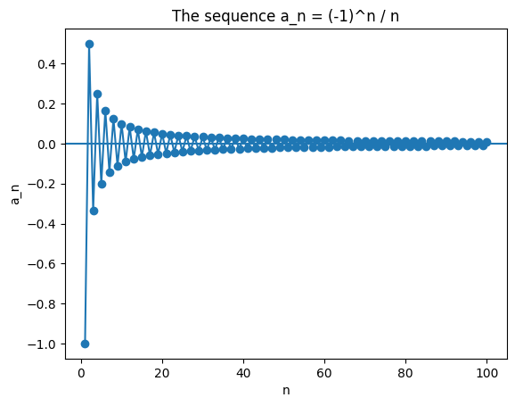

```python
n_values = []
a_values = []

for n in range(1, 101):
    a = ((-1)**n)/n
    n_values.append(n)
    a_values.append(a)

plt.plot(n_values, a_values, marker='o')
plt.axhline(0)
plt.xlabel("n")
plt.ylabel("a_n")
plt.title("The sequence a_n = (-1)^n / n")
plt.show()
```

This sequence converges to 0:

$$ \lim_{n\to\infty}\frac{(-1)^n}{n}=0. $$

The signs keep alternating, but the **tail** gets closer and closer to 0.

## Part 3: Divergence to Infinity

Now consider the sequence

$$ a_n = n. $$

Let's look at some terms.

```python
for n in range(1, 11):
    a = n
    print("a_" + str(n) + " =", a)
```

```
a_1 = 1
a_2 = 2
a_3 = 3
a_4 = 4
a_5 = 5
a_6 = 6
a_7 = 7
a_8 = 8
a_9 = 9
a_10 = 10
```

Now let's look at a later part of the sequence.

```python
for n in range(100, 111):
    a = n
    print("a_" + str(n) + " =", a)
```

```
a_100 = 100
a_101 = 101
a_102 = 102
a_103 = 103
a_104 = 104
a_105 = 105
a_106 = 106
a_107 = 107
a_108 = 108
a_109 = 109
a_110 = 110
```

This sequence does **not** approach a finite number.

The terms keep getting larger and larger. We say the sequence **diverges to infinity**, and we write

$$ a_n \to \infty. $$

This does **not** mean the sequence reaches infinity. It means the terms become arbitrarily large.

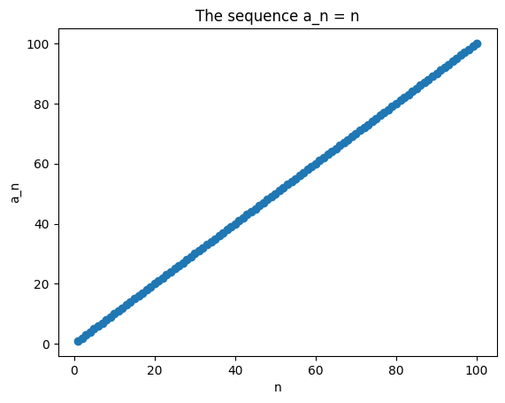

```python
n_values = []
a_values = []

for n in range(1, 101):
    a = n
    n_values.append(n)
    a_values.append(a)

plt.plot(n_values, a_values, marker='o')
plt.xlabel("n")
plt.ylabel("a_n")
plt.title("The sequence a_n = n")
plt.show()
```

## Your Turn 2

Consider the sequence

$$ b_n = n^2. $$

Print the values from $b_1$ to $b_{10}$.

Does this sequence converge, diverge to infinity, or neither?

```python
# Your code here
```

## Part 4: A Sequence That Does Not Converge

Now consider

$$ a_n = (-1)^n. $$

Let's look at the first several terms.

```python
for n in range(1, 11):
    a = (-1)**n
    print("a_" + str(n) + " =", a)
```

```
a_1 = -1
a_2 = 1
a_3 = -1
a_4 = 1
a_5 = -1
a_6 = 1
a_7 = -1
a_8 = 1
a_9 = -1
a_10 = 1
```

This sequence keeps jumping between $-1$ and $1$.

Let's look at the tail.

```python
for n in range(50, 61):
    a = (-1)**n
    print("a_" + str(n) + " =", a)
```

```
a_50 = 1
a_51 = -1
a_52 = 1
a_53 = -1
a_54 = 1
a_55 = -1
a_56 = 1
a_57 = -1
a_58 = 1
a_59 = -1
a_60 = 1
```

### Question 4

Does the tail settle down near one number?

Explain why this sequence does not converge.

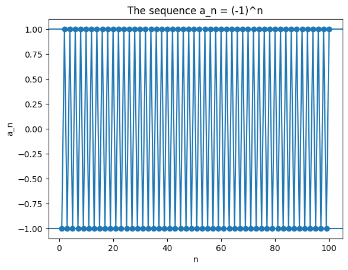

```python
n_values = []
a_values = []

for n in range(1, 101):
    a = (-1)**n
    n_values.append(n)
    a_values.append(a)

plt.plot(n_values, a_values, marker='o')
plt.axhline(1)
plt.axhline(-1)
plt.xlabel("n")
plt.ylabel("a_n")
plt.title("The sequence a_n = (-1)^n")
plt.show()
```

This sequence does **not** converge.

It also does **not** diverge to infinity.

Instead, it keeps oscillating between two values forever.

## Part 5: Tail Detective

For each sequence below, use the code to examine the tail.

Decide whether the sequence:

1. converges to a finite number,
2. diverges to infinity, or
3. does not converge.

### Example A

$$ a_n = 5 - \frac{2}{n} $$

```python
for n in range(100, 111):
    a = 5 - 2/n
    print("a_" + str(n) + " =", a)
```

```
a_100 = 4.98
a_101 = 4.98019801980198
a_102 = 4.980392156862745
a_103 = 4.980582524271845
a_104 = 4.980769230769231
a_105 = 4.980952380952381
a_106 = 4.981132075471698
a_107 = 4.981308411214953
a_108 = 4.981481481481482
a_109 = 4.981651376146789
a_110 = 4.9818181818181815
```

### Example B

$$ a_n = \sqrt{n} $$

```python
import math

for n in range(100, 111):
    a = math.sqrt(n)
    print("a_" + str(n) + " =", a)
```

```
a_100 = 10.0
a_101 = 10.04987562112089
a_102 = 10.099504938362077
a_103 = 10.14889156509222
a_104 = 10.198039027185569
a_105 = 10.246950765959598
a_106 = 10.295630140987
a_107 = 10.344080432788601
a_108 = 10.392304845413264
a_109 = 10.44030650891055
a_110 = 10.488088481701515
```

### Example C

$$ a_n = 2 + (-1)^n $$

```python
for n in range(100, 111):
    a = 2 + (-1)**n
    print("a_" + str(n) + " =", a)
```

```
a_100 = 3
a_101 = 1
a_102 = 3
a_103 = 1
a_104 = 3
a_105 = 1
a_106 = 3
a_107 = 1
a_108 = 3
a_109 = 1
a_110 = 3
```

## Final Reflection

Complete the sentences below.

1. A sequence converges when ...
2. A sequence diverges to infinity when ...
3. The tail of a sequence is important because ...
4. A sequence can fail to converge if ...

## Connection to Function Limits

The same idea will help us understand limits of functions.

For sequences, we ask:

> What happens to $a_n$ when $n$ gets very large?

For functions, we ask:

> What happens to $f(x)$ when $x$ gets close to a certain value?

In both cases, the main idea is that we look at what happens **eventually** or **near the point of interest**, not just at one isolated value.